# R Notebook

```r
library("dplyr")
#date
library("lubridate")
#data manipulation,
library(tidyr)
library(ggplot2)
library(doParallel)
library(randomForest)
```

```r
#change in diagnostic
path = "~/Documents/3eme-annee/Data R/Projet_Sante-/"
setwd(path)
load("dataset.Rdata")
#-----new dataset to make the model
## ------Onehot Encoding to factor
```

```r
data.model <- data
data.model$output <- (substring(names(data[,5:30]),first = 11)[max.col(data[,5:30])])
data.model[,5:30] <- NULL
data.model$output <- as.factor(data.model$output)
#put the original vector
print(str(data.model$diag))
```

```
 Factor w/ 30 levels "Amputation","Anoxia",..: 12 23 12 29 24 19 27 29 24 29 ...
NULL
```

1. description du dataset

```r
str(data.model)
```

```
'data.frame':   1865651 obs. of  15 variables:
 $ date       : Date, format: "2013-01-01" "2013-01-01" "2013-01-01" "2013-01-01" ...
 $ age        : num  57 0.583 59 17 38 ...
 $ sex        : Factor w/ 3 levels "Female","Male",..: 2 1 1 1 2 1 2 1 2 2 ...
 $ race       : Factor w/ 7 levels "Asian","Black",..: 7 1 7 7 7 7 5 4 7 7 ...
 $ diag       : Factor w/ 30 levels "Amputation","Anoxia",..: 12 23 12 29 24 19 27 29 24 29 ...
 $ disposition: Factor w/ 7 levels "Admitted","Died",..: 6 6 6 6 6 6 6 6 6 6 ...
 $ location   : Factor w/ 9 levels "Farm","Home",..: 7 5 2 2 2 7 2 2 2 7 ...
 $ fmv        : Factor w/ 4 levels "Fire dept attended",..: 4 4 4 4 4 4 4 4 4 4 ...
 $ prod1      : Factor w/ 793 levels "102","106","107",..: 715 603 617 754 131 663 653 347 126 698 ...
 $ prod2      : Factor w/ 750 levels "0","102","106",..: 1 1 1 1 1 1 1 1 1 1 ...
 $ stratum    : Factor w/ 5 levels "C","L","M","S",..: 3 3 3 3 3 3 3 4 5 5 ...
 $ psu        : Factor w/ 93 levels "1","2","3","4",..: 92 92 92 92 92 92 92 86 56 56 ...
 $ weight     : num  88.4 88.4 88.4 88.4 88.4 ...
 $ narrative  : chr  "57YOM FELL WHILE JOGGING ON TRAIL DX: CONTUSION TO FACE" "7MOF HIT HEAD ON FLOOR AT DAY-CARE DX: CLOSED HEAD INJURY" "59YOF FELL WHILE ON STAIRS DX: CONTUSION TO BUTTOCKS" "17YOF TWISTED ANKLE STEPPING OUT OF BED DX: ANKLE STRAIN" ...
 $ output     : Factor w/ 25 levels "All Of Body",..: 6 10 15 2 7 25 1 8 12 2 ...
```

# Premier approach

summary

# —— modele un jour

## correlation categorical

**Pearson’s chi-squared test (χ2)** is a statistical test applied to sets of categorical data to evaluate how likely it is that any observed difference between the sets arose by chance. It is the most widely used of many chi-squared tests (e.g., Yates, likelihood ratio, portmanteau test in time series, etc.)

> The measure of association does not indicate causality, but association–that is, whether a variable is associated with another variable. This measure of association also indicates the strength of the relationship, whether, weak or strong. Since,nominal categorical predictor’s, the Goodman and Kruskal’s tau measure is appropriate. Interested readers are invited to see pages 68 and 69 of the Agresti book. More information on this test can be seen here

[link](https://www.r-bloggers.com/to-eat-or-not-to-eat-thats-the-question-measuring-the-association-between-categorical-variables/)

```r
library(GoodmanKruskal)
#categorical data

varset1 <- names(Filter(is.factor,data.full))
varset1
```

```
 [1] "sex"         "race"        "diag"        "disposition" "location"    "prod1"       "prod2"       "stratum"
 [9] "output"      "fmv"         "psu"
```

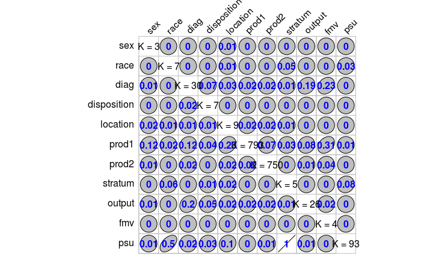

```r
dataFrame1<- subset(data.full, select = varset1)
#make matrix
GKmatrix1<- GKtauDataframe(dataFrame1)
plot(GKmatrix1, corrColors = "blue")
```

```r
#model
table(data.model$output)
```

```
25 - 50% Body   All Of Body         Ankle           Ear         Elbow       Eyeball          Face        Finger
          131         45659        106457         23902         45540         24828        161135        158849
         Foot          Hand          Head      Internal          Knee     Lower Arm     Lower Leg   Lower Trunk
        83108         89045        304331         18211         98782         69459         65936        156722
        Mouth          Neck      N.S./Unk  Pubic Region      Shoulder           Toe     Upper Arm     Upper Leg
        38972         32058         12795          9178         75142         37741         21211         22233
  Upper Trunk         Wrist
       102698         61528
```

# Creation d’un dataset output

Dataset avec 5000 observation par niveau du Output :: Obj: l’effect du desequilibre dans le dataset

```r
## creation of the balanced dataset
levels(data.model$output)[1] <- levels(data.model$output)[2]  # remove "25% body" factor, it becomes all body
table(data.model$output)

#create a dataset with 5000 samples by factor
sel <- subset(data.model, data.model$output == levels(data.model$output)[1]) #get obs from all body
data.good <- sel[sample(1:nrow(sel),5000),]

#get from the others
for(l in levels(data.model$output)[-1]){
  sel <- subset(data.model, data.model$output == l)
  data.good <- rbind(data.good, sel[sample(1:nrow(sel),5000),])
}
### new dataset
str(data.good)
head(data.good)
save(data.good,file ="dataset_balanced.Rdata")
```

### function to plot the confusion matrix

```r
plot_confusion_matrix <- function(out.pred,true.label,title){
                        mat <- as.data.frame(prop.table(table(out.pred,true.label),1)) #normalize by class
                        plot <- ggplot(mat,aes(x = out.pred,y=true.label,fill=Freq))+
                                geom_tile()+
                                ggtitle(title)+
                                theme(axis.text.x = element_text(angle=45, hjust = 1))+ #incline text
                                xlab("true.label")+
                                xlab("predicted")
                        return(plot)
}
```

## model output

Chaque variable comme numerique et factor

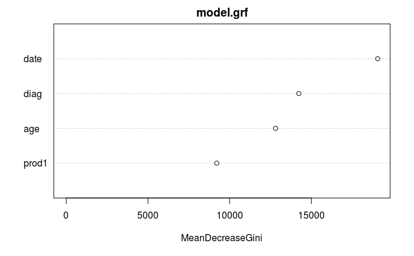

#model numerique

Variables numeriques

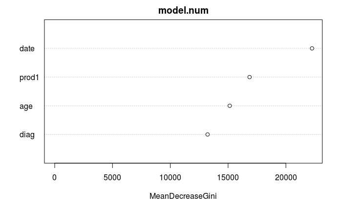

#model numerique aleatoire

Not-balanced dataset

```r
load("dataset_model.Rdata")
dataset <- data.model[,c("date","age","diag","prod1","output")]
dataset <- dataset[sample(1:nrow(dataset),125000),] #permute dataset
print(table(dataset$output))
```

```
 All Of Body        Ankle          Ear        Elbow      Eyeball         Face       Finger         Foot         Hand
        3013         7151         1575         3074         1639        10708        10574         5625         5942
        Head     Internal         Knee    Lower Arm    Lower Leg  Lower Trunk        Mouth         Neck     N.S./Unk
       20618         1185         6813         4485         4412        10474         2559         2118          889
Pubic Region     Shoulder          Toe    Upper Arm    Upper Leg  Upper Trunk        Wrist
         628         4935         2557         1464         1442         6922         4198
```

```r
dataset$diag <-as.numeric(dataset$diag)
dataset$prod1 <-as.numeric(dataset$prod1)

test_size <- round(0.7 * nrow(dataset))
train_data3 = dataset[1:test_size,]
test_data3 = dataset[-(1:test_size),]

set.seed(12345)
model.num.al <- randomForest( output ~. , data = train_data3, ntree = 100)
print(model.num.al)
```

```
Call:
 randomForest(formula = output ~ ., data = train_data3, ntree = 100)
               Type of random forest: classification
                     Number of trees: 100
No. of variables tried at each split: 2

        OOB estimate of  error rate: 60.99%
Confusion matrix:
             All Of Body Ankle Ear Elbow Eyeball Face Finger Foot Hand  Head Internal Knee Lower Arm Lower Leg
All Of Body         1449    18  12     7      20   22     12   18   11    18        0   79        10        12
Ankle                 19  2662   3    55       7  120    241  163   68    27        0  387       101       106
Ear                    2     2 591     6      15  234     53   24   11    54        0    8        10        11
Elbow                  6   154   8   315      13  164    132   97   61    78        0  154       251        85
Eyeball               22     8  19    19     432  136     62   57   42    27        0   59        27        27
Face                  29    90 103    66      78 3879    419  175  233   810        0  214       144       174
Finger                17   429  61    85      50  587   3863  199  533   150        0  178       230       120
Foot                  16   530  30    65      66  343    357  776  207   101        0  204       119       119
Hand                  14   129  11    43      59  362   1126  209 1062   121        0  138       169        92
Head                  25    30  21    45      31 1559    187   86  117 11184        0  162        67        95
Internal               0     0   0     0       0    0      1    0    1     0      840    0         0         0
Knee                  42   969   7    81      37  317    228  171  109   126        0  709        46       116
Lower Arm             14   112   6   131      35  276    410  102  258   112        0   76       709       156
Lower Leg             21   220  13    69      44  409    323  146  130   181        0  197       229       255
Lower Trunk           90   741  25    82      39  262    160  191  120   217        0  652        60       145
Mouth                  2     3  21     5      11  892    100   19   26   115        2   19         6        22
Neck                  14   302   8    17      12   43     43   36   32    19        0  141        21        27
N.S./Unk              34     6   1     8      11   23      8   11    8    18        0   46        13        21
Pubic Region           9     5  17    11      22  110     21   18    5    23        0   21         6        16
Shoulder              30   397   5    88      25  100    200   83   84    65        0  363       147        94
Toe                    6    96   7    32      30  188    298  163  129    67        0   71        77        47
Upper Arm              2    60   4    40       6   51     56   29   31    25        0   36       173        50
Upper Leg              6    90   3    17      14   82    124   40   43    45        0   50        48        41
Upper Trunk           92   320  23    62      56  218    136  183  151   256        1  432        99       115
Wrist                 14   529   3    69      13  106    303  125  149    38        0  161       344        82
             Lower Trunk Mouth Neck N.S./Unk Pubic Region Shoulder Toe Upper Arm Upper Leg Upper Trunk Wrist
All Of Body          189     4    8       38            3       23   8         2         4         145     5
Ankle                547     3   80        3            3      148  39        18        12         168   148
Ear                   21    12    5        0            7        2   5         2         2          14     3
Elbow                188     7   22        9            5      100  24        21        10         103    82
Eyeball               75     8    6        5           11       16  12         3         5          81    10
```

[output cut: 31 more lines]

```
Internal     0.002375297
Knee         0.851983299
Lower Arm    0.773192578
Lower Leg    0.918243027
Lower Trunk  0.601277000
Mouth        0.717439294
Neck         0.968328841
N.S./Unk     0.819078947
Pubic Region 0.969696970
Shoulder     0.862590975
Toe          0.897149245
Upper Arm    0.965517241
Upper Leg    0.968379447
Upper Trunk  0.820917203
Wrist        0.928423950
```

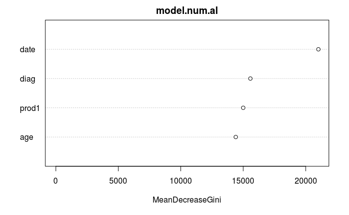

```r
varImpPlot(model.num.al)
```

```r
out.pred3 <- predict(model.num.al, train_data3[,-5]) #all data, mtry auto, 100nt
out.pred3.t <- predict(model.num.al, test_data3[,-5]) #all data, mtry auto, 100nt
```

##results

[figure not shown]

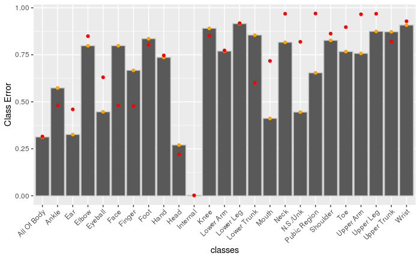